# HW3 - Forecasting

### Exercise 5.7

#### For your retail time series (from Exercise 8 in Section 2.10):

#### Create a training dataset consisting of observations before 2011 using:

```r
#code to generate dataset the same as in HW2
set.seed(8675309)
myseries <- aus_retail %>%
  filter(`Series ID` == sample(aus_retail$`Series ID`,1))


myseries_train <- myseries %>%
  filter(year(Month) < 2011)
```

#### Check that your data have been split appropriately by producing the following plot.

It looks like the red data is the appropriate training data, and we’re omitting the black line for now (so we can test our prediction later).

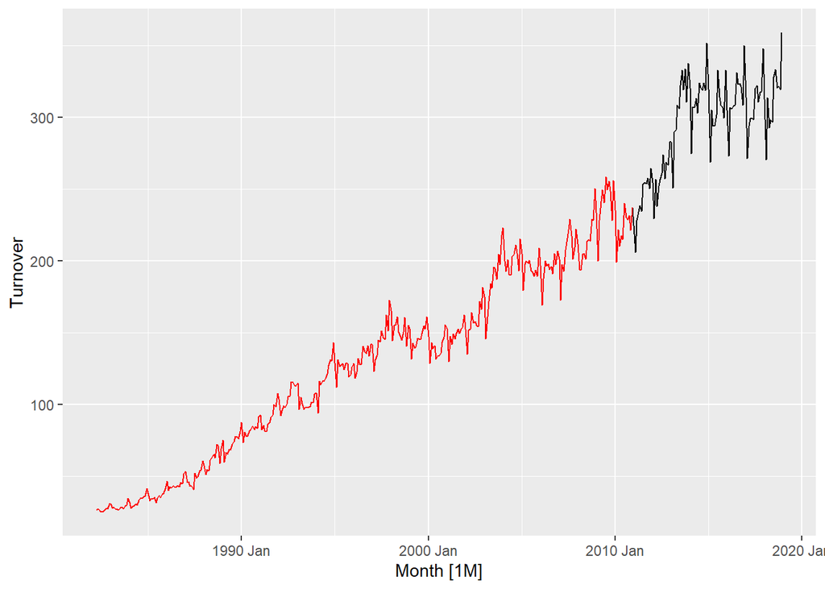

```r
autoplot(myseries, Turnover) +
  autolayer(myseries_train, Turnover, colour = "red")
```

#### Fit a seasonal naïve model using SNAIVE() applied to your training data (myseries_train).

```r
fit <- myseries_train %>%
          model(SNAIVE(Turnover))
```

#### Check the residuals. Do the residuals appear to be uncorrelated and normally distributed?

The residuals get worse as time goes on, which suggests I might want to look into a box-cox transformation on the data which I’d suspect might suggest a log transformation. Further the ACF plot shows the data is correlated and we should investigate an appropriate lag for the seasonality. The histogram mostly has the shape of a normal distribution, but it is not centered around zero. We have some work to do.

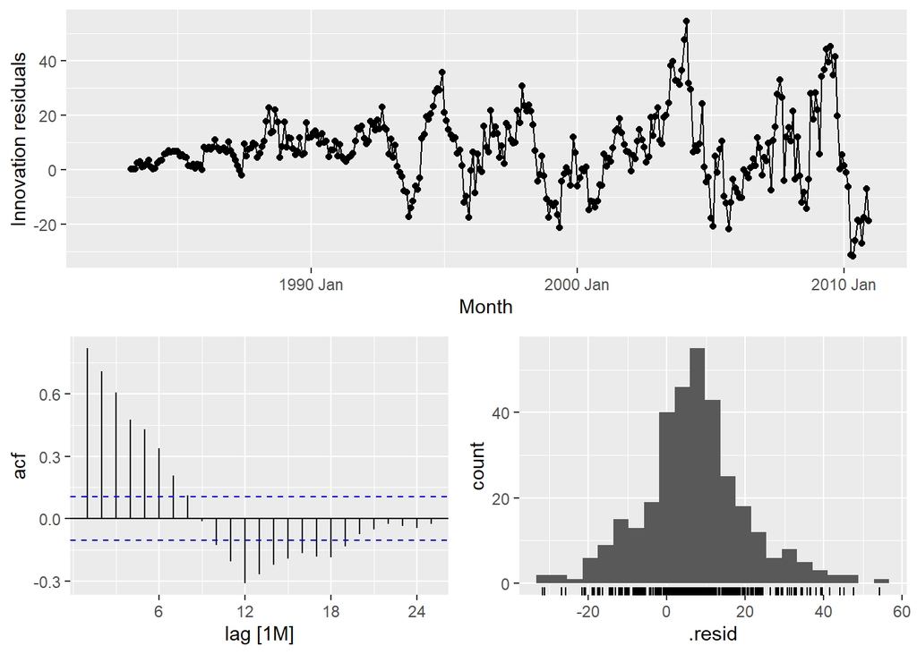

```r
fit %>% gg_tsresiduals()
```

#### Produce forecasts for the test data

With the forecasts based on the troublesome fit generated above, we see the forecast is quite a bit off, it assumes a similar level (with seasonality) and doesn’t capture the jump the actual test data provides.

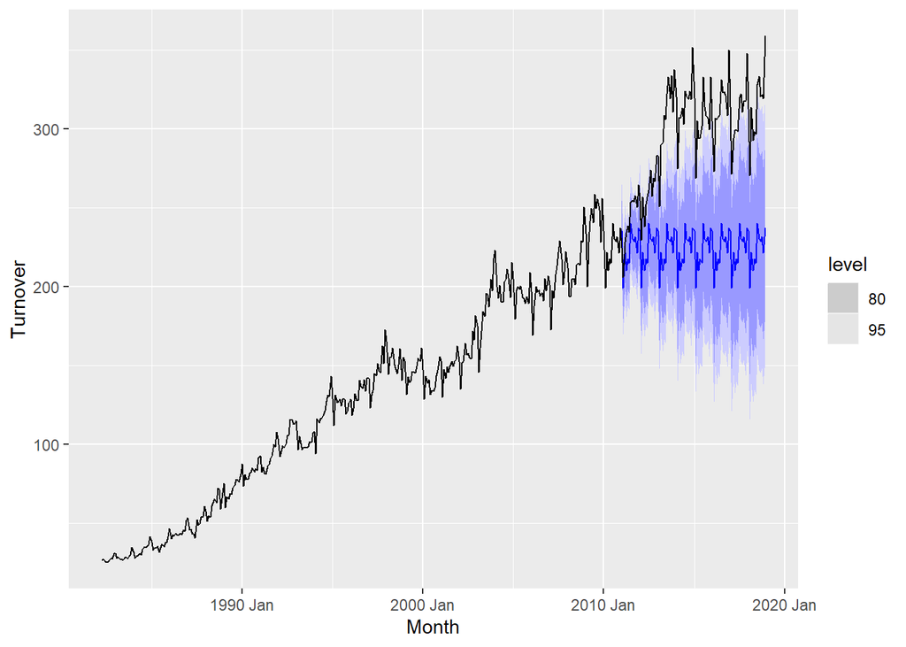

```r
fc <- fit %>%
  forecast(new_data = anti_join(myseries, myseries_train))
fc %>% autoplot(myseries)
```

#### Compare the accuracy of your forecasts against the actual values.

In looking at the model vs the real series there are more errors across all of the measures. This is expected when looking at the plot above, as since a major increase in turnover wasn’t forecast, the amount of error is large.

```r
fit %>% accuracy()
```

```
## # A tibble: 1 x 12
##   State  Industry   .model .type    ME  RMSE   MAE   MPE  MAPE  MASE RMSSE  ACF1
##   <chr>  <chr>      <chr>  <chr> <dbl> <dbl> <dbl> <dbl> <dbl> <dbl> <dbl> <dbl>
## 1 Queen~ Takeaway ~ SNAIV~ Trai~  7.07  15.0  11.5  6.79  9.57     1     1 0.818
```

```r
fc %>% accuracy(myseries)
```

```
## # A tibble: 1 x 12
##   .model   State Industry  .type    ME  RMSE   MAE   MPE  MAPE  MASE RMSSE  ACF1
##   <chr>    <chr> <chr>     <chr> <dbl> <dbl> <dbl> <dbl> <dbl> <dbl> <dbl> <dbl>
## 1 SNAIVE(~ Quee~ Takeaway~ Test   71.6  77.4  71.9  23.4  23.5  6.23  5.16 0.861
```

#### How sensitive are the accuracy measures to the amount of training data used?

This is always a delicate balance from what I’ve read. If too much similar data is provided as a training set there is a risk of over-training the model and it may perform poorly in forecasting. If not enough, or not diverse enough, training data is provided than the model may be too simple and miss important patterns.